# R4DS Ch 16 Exercises

Chris Sirico

10/19/2017

## 16.2.4 Exercises

1. **What happens if you parse a string that contains invalid dates?**

   ```r
   ymd(c("2010-10-10", "bananas"))
   ```

   It parses the rest and throws a warning.

   ```
   ## Warning: 1 failed to parse.
   ```

   ```
   ## [1] "2010-10-10" NA
   ```

2. **What does the `tzone` argument to `today()` do? Why is it important?**

It tells the function what timezone to evaluate that date in at the time it’s run. It’s important because it’s not the same day at the same time in different parts of the world.

3. **Use the appropriate lubridate function to parse each of the following dates:**

```r
    d1 <- "January 1, 2010"
mdy(d1)
```

```
## [1] "2010-01-01"
```

```r
    d2 <- "2015-Mar-07"
ymd(d2)
```

```
## [1] "2015-03-07"
```

```r
    d3 <- "06-Jun-2017"
dmy(d3)
```

```
## [1] "2017-06-06"
```

```r
    d4 <- c("August 19 (2015)", "July 1 (2015)")
mdy(d4)
```

```
## [1] "2015-08-19" "2015-07-01"
```

```r
    d5 <- "12/30/14" # Dec 30, 2014
mdy(d5)   # déjà vu...🤔
```

```
## [1] "2014-12-30"
```

## 16.3.4 Exercises

1. **How does the distribution of flight times within a day change over the course of the year?**

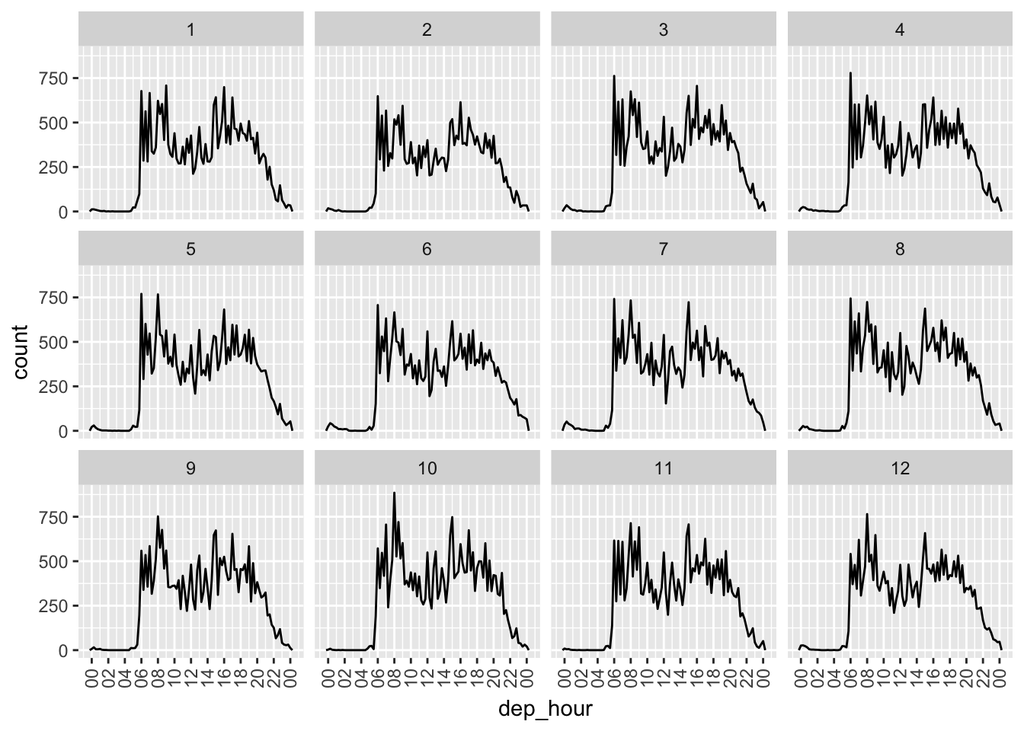

```
Seems to stay mostly constant except for a little noise. More years' data and summary by different measures might yield some trends. If anything, I might say departure times skew from 6 am to 8 am from beginning to end of year, but that could easily be a fluke.
```

```r
make_datetime_100 <- function(year, month, day, time) {
  make_datetime(year, month, day, time %/% 100, time %% 100)
}

#create flights_dt
flights_dt <- flights %>%
  filter(!is.na(dep_time), !is.na(arr_time)) %>%
  mutate(
    dep_time = make_datetime_100(year, month, day, dep_time),
    arr_time = make_datetime_100(year, month, day, arr_time), # Aha! Assuming arrival time is same date as y/m/d
                                                              # (actually departure? scheduled departure?)
    sched_dep_time = make_datetime_100(year, month, day, sched_dep_time),
    sched_arr_time = make_datetime_100(year, month, day, sched_arr_time) # Same issue here
  ) %>%
  select(origin, dest, ends_with("delay"), ends_with("time"))


flights_dt %>%
  mutate(mnth = month(dep_time)) %>% # re-create a month variable to facet by
  #group_by(month) %>%
  mutate(dep_hour = update(dep_time, yday = 1)) %>% # update() voodoo -- make every flight one day
  ggplot(aes(dep_hour)) +
    geom_freqpoly(binwidth = 900) +
    scale_x_datetime(date_breaks = "2 hours", date_labels = "%H") +
    theme(axis.text.x = element_text(angle = 90, hjust = 1, vjust = .5)) +
    facet_wrap(~mnth) # Not sure how to make these labels month names.
```

2. **Compare `dep_time`, `sched_dep_time` and `dep_delay`. Are they consistent? Explain your findings.**

```r
# Interesting note: comparing dep_time, sched_dep_time and time_hour in View(flights) shows that dates refer to date of ACTUAL departure (same is true for year/month/day columns), but date_time times refer to SCHEDULED departure times. See rows 843-844, illustrated in the middle of the figure below:
flights %>%
  filter(!is.na(dep_time), !is.na(arr_time), row_number() > 835, row_number() < 848) %>%
  select(origin, dest, ends_with("delay"), contains("time")) %>% print()
```

[output not shown]

```r
# Re-create flights_dt
flights_dt <- flights %>%
  filter(!is.na(dep_time), !is.na(arr_time)) %>%
  mutate(
    dep_time = make_datetime_100(year, month, day, dep_time),
    arr_time = make_datetime_100(year, month, day, arr_time), # Assumes arrival time is same date as y/m/d
    sched_dep_time = make_datetime_100(year, month, day, sched_dep_time),
    sched_arr_time = make_datetime_100(year, month, day, sched_arr_time) # Same issue
  ) %>%
  select(origin, dest, ends_with("delay"), ends_with("time"))

# See the issue illustrated here in rows 3-4.
flights_dt %>%
mutate(dep_delay_2 = (dep_time - sched_dep_time)/60) %>%
    filter(row_number() > 835, row_number() < 848) %>% print()
```

```
## # A tibble: 12 x 10
##    origin  dest dep_delay arr_delay            dep_time
##     <chr> <chr>     <dbl>     <dbl>              <dttm>
##  1    JFK   SJU        -6       -24 2013-01-01 23:53:00
##  2    JFK   BQN        -3       -12 2013-01-01 23:56:00
##  3    JFK   SJU        43        36 2013-01-02 00:42:00
##  4    JFK   SYR       156       154 2013-01-02 01:26:00
##  5    EWR   CLT        -2        13 2013-01-02 04:58:00
##  6    EWR   IAH        -3       -10 2013-01-02 05:12:00
##  7    JFK   MIA        -5       -19 2013-01-02 05:35:00
##  8    LGA   IAH         7        12 2013-01-02 05:36:00
##  9    JFK   BQN        -6       -23 2013-01-02 05:39:00
## 10    JFK   FLL        -6       -16 2013-01-02 05:54:00
## 11    JFK   PBI        -6       -10 2013-01-02 05:54:00
## 12    LGA   FLL        -6        11 2013-01-02 05:54:00
## # ... with 5 more variables: sched_dep_time <dttm>, arr_time <dttm>,
## #   sched_arr_time <dttm>, air_time <dbl>, dep_delay_2 <time>
```

3. **Compare `air_time` with the duration between the departure and arrival. Explain your findings. (Hint: consider the location of the airport.)**

```r
flights_dt %>%
mutate(air_time_2 = (arr_time - dep_time)) %>% print()
```

```
## # A tibble: 328,063 x 10
##    origin  dest dep_delay arr_delay            dep_time
##     <chr> <chr>     <dbl>     <dbl>              <dttm>
##  1    EWR   IAH         2        11 2013-01-01 05:17:00
##  2    LGA   IAH         4        20 2013-01-01 05:33:00
##  3    JFK   MIA         2        33 2013-01-01 05:42:00
##  4    JFK   BQN        -1       -18 2013-01-01 05:44:00
##  5    LGA   ATL        -6       -25 2013-01-01 05:54:00
##  6    EWR   ORD        -4        12 2013-01-01 05:54:00
##  7    EWR   FLL        -5        19 2013-01-01 05:55:00
##  8    LGA   IAD        -3       -14 2013-01-01 05:57:00
##  9    JFK   MCO        -3        -8 2013-01-01 05:57:00
## 10    LGA   ORD        -2         8 2013-01-01 05:58:00
## # ... with 328,053 more rows, and 5 more variables: sched_dep_time <dttm>,
## #   arr_time <dttm>, sched_arr_time <dttm>, air_time <dbl>,
## #   air_time_2 <time>
```

Most flights don’t match up, largely because of differing time zones. Even within timezones, there are discrepancies between the difference of departure and arrival times and the air_time measurement. This could have to do with taxi times.

4. **How does the average delay time change over the course of a day? Should you use `dep_time` or `sched_dep_time`? Why?**

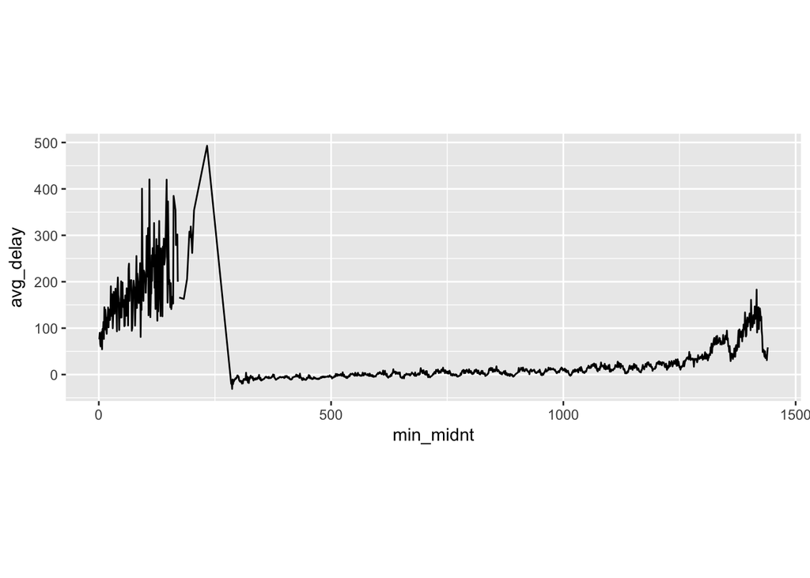

```r
# Create a new data frame
flights_dt2 <- flights %>%
  filter(!is.na(dep_time), !is.na(arr_time)) %>%
  mutate(
    dep_time_psx = make_datetime_100(year, month, day, dep_time), # create new names for POSIX columns so
    arr_time_psx = make_datetime_100(year, month, day, arr_time), # we can maintain originals
    sched_dep_time_psx = make_datetime_100(year, month, day, sched_dep_time),
    sched_arr_time_psx = make_datetime_100(year, month, day, sched_arr_time)
  ) %>%
  select(dest, contains("delay"), contains("time")) # Don't really need origin--somewhere around NYC!

flights_dt2 %>%
  mutate(min_midnt = dep_time %/% 100 * 60 + dep_time %% 100) %>% #convert to minutes since midnight
  group_by(min_midnt) %>%
  summarise(avg_delay = mean(arr_delay, na.rm = TRUE),
    n = n()) %>%
  ggplot(aes(min_midnt, avg_delay)) +
    geom_line() +
  coord_fixed()
```

It increases, likely due to the knock-on effect of delays. Post midnight flights have higher average delays because there are none scheduled–we’re artificially selecting for only delayed flights during down hours.

5. **On what day of the week should you leave if you want to minimise the chance of a delay?**

Saturday

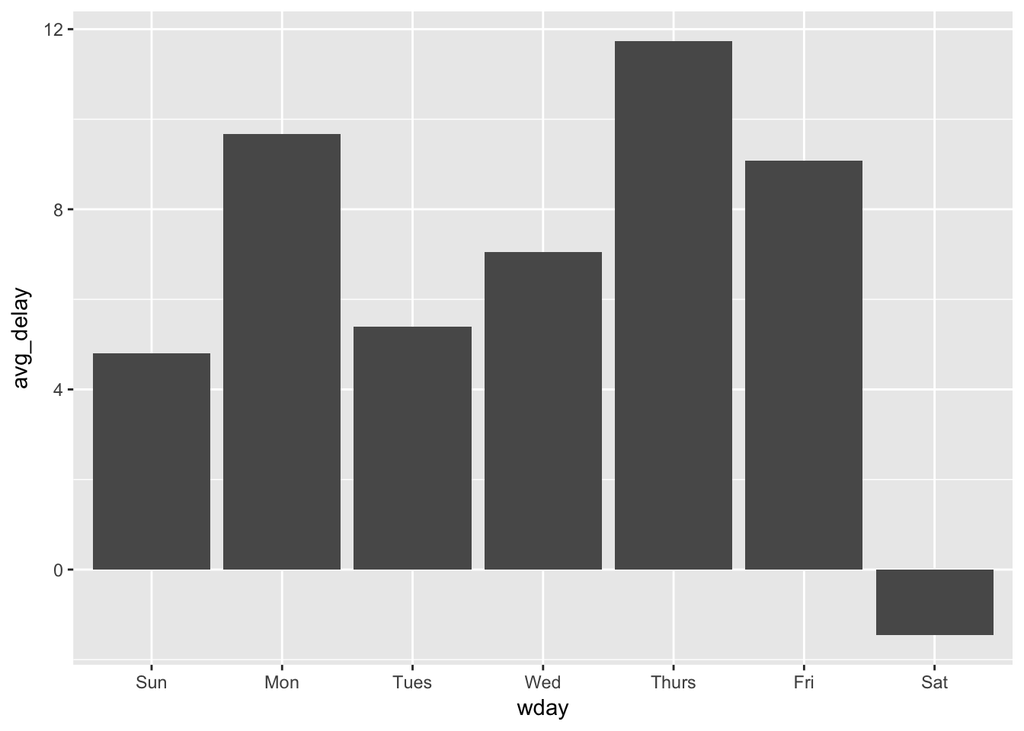

```r
flights_wk <- flights_dt %>%
  mutate(wday = wday(dep_time, label = TRUE)) %>%
  group_by(wday) %>%
  summarize(avg_delay = mean(arr_delay, na.rm=T)) # %>% #View()
  ggplot(flights_wk) +
    geom_col(aes(wday, avg_delay))
```

6. **What makes the distribution of `diamonds$carat` and `flights$sched_dep_time` similar?**

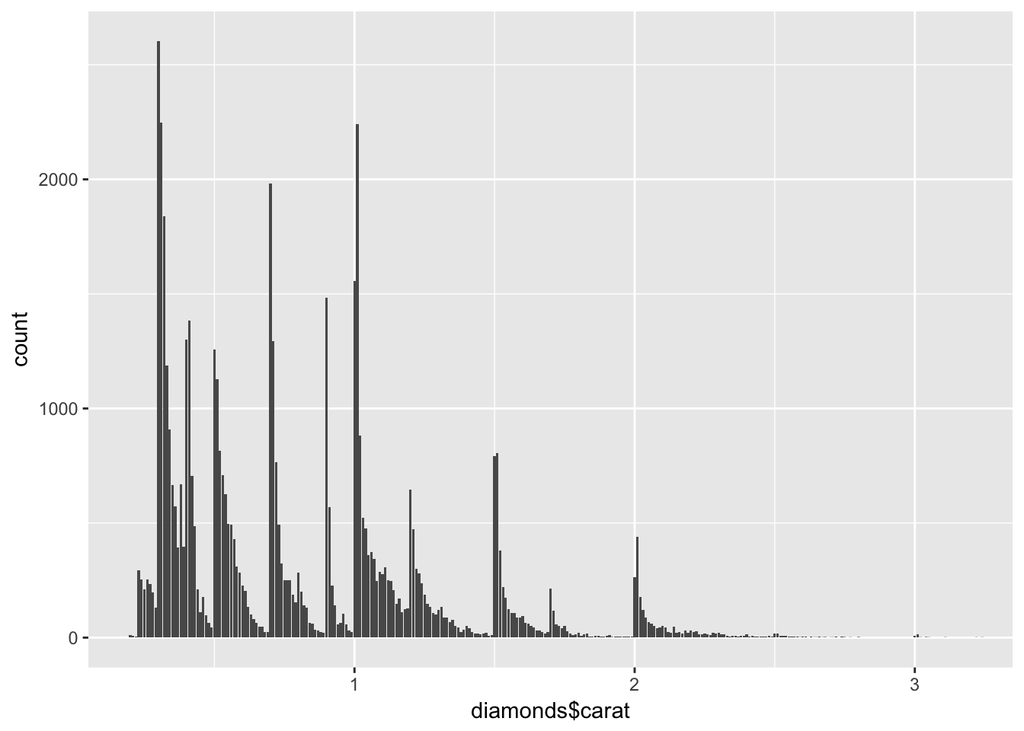

```r
ggplot() +
  geom_bar(aes(diamonds$carat))+
    coord_cartesian(xlim = c(.2, 3.2))
```

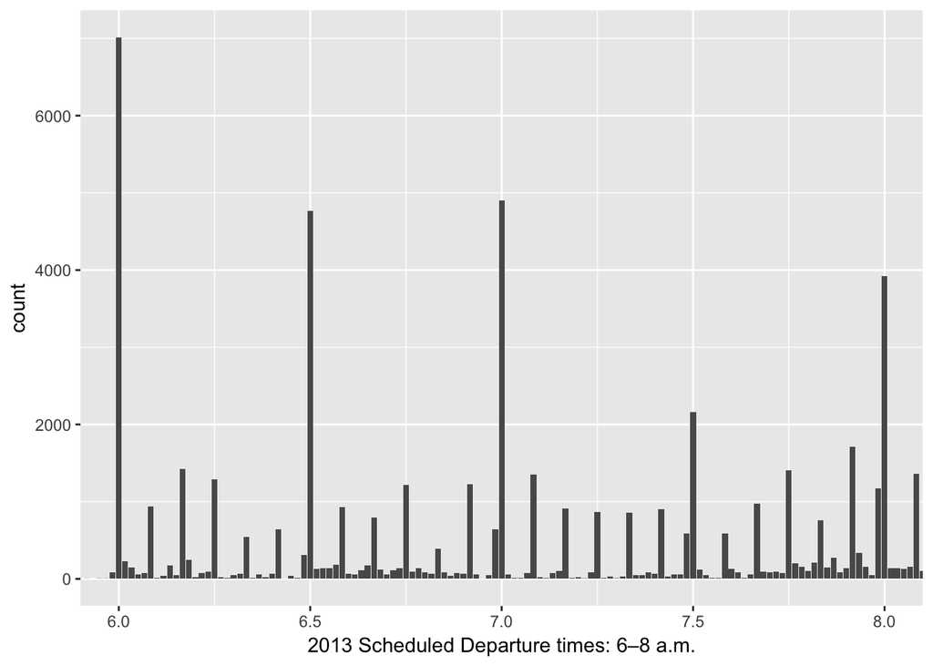

```r
ggplot() +
  geom_bar(aes(flights$sched_dep_time %/% 100 + flights$sched_dep_time %% 100 /
                 60))+
    coord_cartesian(xlim = c(6, 8)) +
  labs(x = "2013 Scheduled Departure times: 6–8 a.m.")
```

They both cluster around nice, round numbers (5- and 30-minute increments, in this case).

7. **Confirm my hypothesis that the early departures of flights in minutes 20-30 and 50-60 are caused by scheduled flights that leave early. Hint: create a binary variable that tells you whether or not a flight was delayed.**

Original chart:

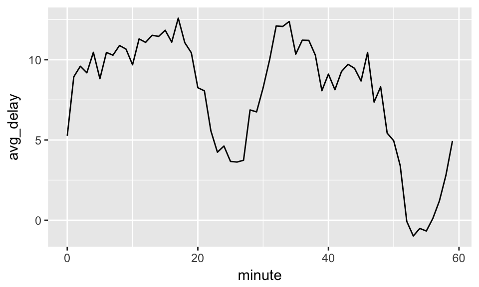

With early departures (negative delays) removed:

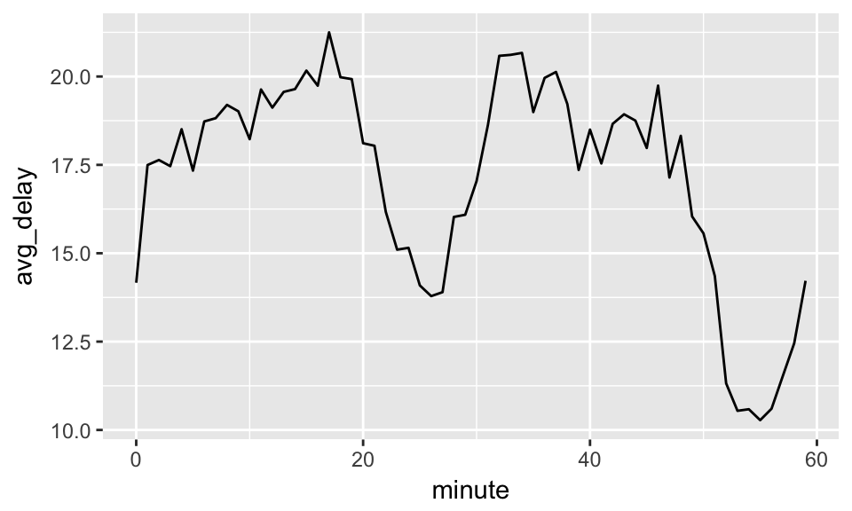

```r
# Code for above
flights_dt %>%
  mutate(minute = minute(dep_time),
         early = (arr_delay < 0),
         arr_delay = ifelse(early == TRUE, 0, arr_delay)) %>% # make delays 0 if negative
  group_by(minute) %>%
  summarise(
    avg_delay = mean(arr_delay, na.rm = TRUE),
    n = n()) %>%
  ggplot(aes(minute, avg_delay)) +
    geom_line()
```

The proposed hypothesis doesn’t bear out. The variation in delays is more likely caused by the increased numbers of departure times scheduled on the hour and half-hour (see bar graph above).

## 16.4.5 Exercises

1. **Why is there `months()` but no `dmonths()`?**

Months don’t have a standard duration.

2. **Explain `days(overnight * 1)` to someone who has just started learning R. How does it work?**

   `days()` adds a day of appropriate length for the date (it accounts for DST, leap years, leap seconds, etc.). Overnight is a logical that specifies whether a flight spanned midnight. When overnight is TRUE, `days(overnight * 1)` returns a period of one day, which we add to erroneous flight records so they don’t show flights arriving 23 hours in the past!
3. **Create a vector of dates giving the first day of every month in 2015. Create a vector of dates giving the first day of every month in the *current* year.**

```r
mdy("01-01-2015") + months(0:11)
```

```
##  [1] "2015-01-01" "2015-02-01" "2015-03-01" "2015-04-01" "2015-05-01"
##  [6] "2015-06-01" "2015-07-01" "2015-08-01" "2015-09-01" "2015-10-01"
## [11] "2015-11-01" "2015-12-01"
```

```r
mdy(paste0("01-01-", as.character(year(today())))) + months(0:11)
```

```
##  [1] "2017-01-01" "2017-02-01" "2017-03-01" "2017-04-01" "2017-05-01"
##  [6] "2017-06-01" "2017-07-01" "2017-08-01" "2017-09-01" "2017-10-01"
## [11] "2017-11-01" "2017-12-01"
```

4. **Write a function that given your birthday (as a date), returns how old you are in years.**

```r
# Okay, so this should be easy. Subtract birth date from today().

get_age <- function(x) { #input age; Month / Day / Year form as a string
  x <- lubridate::mdy(x)
  now() - x  # Hmm...returns days. Could divide by 365, but that would only be an approximation.
}

# Let's subtract birth year from current year, then subtract 1 if the date hasn't yet elapsed.

get_age_yrs <- function(x) { #input age
  x <- lubridate::mdy(x)
  y <- year(lubridate::today()) - year(x)
  year(x) <- year(lubridate::today())
  ifelse (x - lubridate::today() < 0, paste0(y, " years"), paste0(y-1, " years"))
}
get_age_yrs("4-17-88") # Leap day babies might mess things up at the end of Feb.
```

```
## [1] "29 years"
```

```r
# That may have been the hard way. With an interval:
ageme <- function(x) { #input age
  x <- lubridate::ymd(x)
  x %--% today() %/% years(1)
}
ageme("88-10-23") #nifty. I bet this works with leap babies too, as well as anything can.
```

```
## Note: method with signature 'Timespan#Timespan' chosen for function '%/%',
##  target signature 'Interval#Period'.
##  "Interval#ANY", "ANY#Period" would also be valid
```

```
## [1] 28
```

5. **Why can’t `(today() %--% (today() + years(1)) / months(1)` work?**

Because there’s not a close parenthesis!